# Sentiment Analysis of Financial News

The data source is available at [Kaggle](https://www.kaggle.com/datasets/ankurzing/sentiment-analysis-for-financial-news?resource=download).

**Context**: This dataset (FinancialPhraseBank) contains the sentiments for financial news headlines from the perspective of a retail investor.

```python
import plot_pie

import time
import os

import pandas as pd
import numpy as np

import matplotlib.pyplot as plt
import seaborn as sns

import nltk
from nltk.tokenize import word_tokenize
from nltk.corpus import stopwords
# nltk.download('stopwords')
# nltk.download('punkt')

import transformers # transformers library by Hugging Face
from transformers import MarianMTModel, pipeline

import torch
import torch.nn as nn
import torch.optim as optim
from torch.utils.data import Dataset, DataLoader
from torch.nn.utils.rnn import pad_sequence


# from torchtext.vocab import GloVe
# from torchtext.data.utils import get_tokenizer

from sklearn.model_selection import train_test_split, GridSearchCV, cross_val_score
from sklearn.preprocessing import LabelEncoder
from sklearn.metrics import accuracy_score, precision_recall_fscore_support, confusion_matrix, ConfusionMatrixDisplay,  precision_score, recall_score, f1_score, classification_report
from sklearn.linear_model import LogisticRegression
from sklearn.feature_extraction.text import CountVectorizer
from sklearn.naive_bayes import MultinomialNB

from textblob import TextBlob

import string

import pickle
import joblib
```

We first do a GPU check.

```python
print(torch.version.cuda)
print(torch.cuda.is_available())  # Should return True if CUDA is available
print(torch.cuda.device_count())
print(torch.cuda.current_device())
print(torch.cuda.get_device_name(torch.cuda.current_device()))
```

```
12.4
True
1
0
NVIDIA GeForce GTX 960M
```

```python
os.getcwd()
```

```
'D:\\Data\\PyCharmProjects\\MAS-sentiment-analysis\\sent_analysis'
```

This time around we use the balanced data augmented from Groq.com.

```python
data = pd.read_csv("D:\Data\PyCharmProjects\MAS-sentiment-analysis\data/balanced_negative_positive.csv")
data.sample(10)
```

|  | sentiment | news |
| --- | --- | --- |
| 4181 | neutral | Atria said its offer would give the Swedish co... |
| 590 | positive | Increased trust of our clients in YIT can be s... |
| 2051 | positive | The new office , located in Shenzhen , will st... |
| 1746 | neutral | Affecto has helped SKAT to set up the platform... |
| 6358 | negative | Scores of cargo ships stranded in critical shi... |
| 2190 | positive | SOUTHFIELD , Mich. -- Central Corporate Credit... |
| 4385 | negative | The situation of coated magazine printing pape... |
| 4546 | neutral | BioTie North-American licensing partner Somaxo... |
| 8016 | positive | The newly developed residential complex will b... |
| 1493 | positive | A realignment of interests in the sector is cl... |

```python
data.info()
```

```
<class 'pandas.core.frame.DataFrame'>
RangeIndex: 8021 entries, 0 to 8020
Data columns (total 2 columns):
 #   Column     Non-Null Count  Dtype
---  ------     --------------  -----
 0   sentiment  8021 non-null   object
 1   news       8021 non-null   object
dtypes: object(2)
memory usage: 125.5+ KB
```

Our dataframe consists of 8021 rows away from the initial 4,846 rows with just two columns i.e sentiment and news.

## Data Analysis

```python
value_counts = data['sentiment'].value_counts(normalize=True) * 100  # Get percentages
count_with_percentages = data['sentiment'].value_counts().to_frame('counts')  # Get counts
count_with_percentages['percentage'] = round(value_counts, 2)  # Add percentages to the DataFrame

print(count_with_percentages)
```

```
           counts  percentage
sentiment
neutral      2879       35.89
positive     2726       33.99
negative     2416       30.12
```

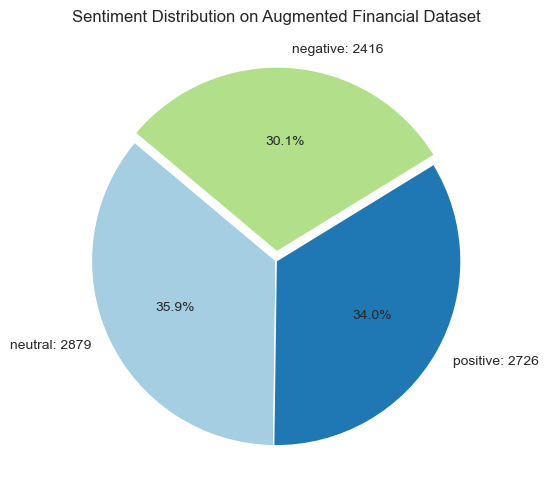

```python
plot_pie.pie_plot(data, 'Sentiment Distribution on Augmented Financial Dataset')
```

## Data Preprocessing

Data cleaning:

```python
# List of strings to delete
strings_to_delete = [
    "Here is a generated headline:\n\n",
    "Here is the headline:\n\n",
    "Here's a generated headline:\n\n",
    "Here's a similar headline:\n\n",
    "Here is a similar headline:\n\n",
    "Here is a headline:\n\n",
    "Here's a headline:\n\n",
    "Here's a potential headline:\n\n",
    "Here is a similar headline:",
    "Here is a potential headline:\n\n",
    "Here is the generated headline:\n\n",
    "Here is the generated headline:",
    "\n\n(Note: Hypothetical data augmentation, real data may vary)",
    "\n\nLet me know if you want me to generate another one!",
    "Here is a headline similar to the one provided:\n\n",
    "\n\nPlease let me know if this meets your requirements.",
    "\n\nLet me know if you'd like me to generate another one!",
    "Here is a generated headline similar to the one you provided:\n\n"
]

# Combine all the strings into a single pattern
pattern = '|'.join([f"{string}" for string in strings_to_delete])

# Replace the unwanted strings with an empty string in the 'news' column
data['news'] = data['news'].replace(pattern, "", regex=True)

# Display the updated dataframe
# print(data['news'])
```

```python
data.to_csv("D:\Data\PyCharmProjects\MAS-sentiment-analysis\data/balanced_all_clean_v1.csv",
                  index=False)
```

```python
# data = df_cleaned.copy()
data.info()
```

```
<class 'pandas.core.frame.DataFrame'>
RangeIndex: 8021 entries, 0 to 8020
Data columns (total 2 columns):
 #   Column     Non-Null Count  Dtype
---  ------     --------------  -----
 0   sentiment  8021 non-null   object
 1   news       8021 non-null   object
dtypes: object(2)
memory usage: 125.5+ KB
```

```python
data.news.iloc[6709]
```

```
'Stocks in Telekomunikasi Indonesia soared after the company released its quarterly earnings report, showcasing a significant surge in profits and a substantial gain in market share.'
```

```python
data.drop(index=6709, inplace=True)
```

```python
# Encode the sentiment labels to integers
label_encoder = LabelEncoder()
data['sentiment_encoded'] = label_encoder.fit_transform(data['sentiment'])
```

With the encoder, we have

- negative = 0,
- neutral = 1,
- positive = 2.

```python
data.sample(50)
```

|  | sentiment | news | sentiment_encoded |
| --- | --- | --- | --- |
| 5075 | negative | Initially, the company anticipated a total of ... | 0 |
| 1748 | positive | At the seminar , a memorandum of understanding... | 2 |
| 3575 | neutral | Eero Katajavuori , currently Group Vice Presid... | 1 |
| 5807 | negative | 22 April 2022 - Analysts at Deutsche Bank fore... | 0 |
| 2603 | neutral | The company 's share is quoted on NASDAQ OMX H... | 1 |
| 2204 | positive | The company also expects to sell its products ... | 2 |
| 129 | positive | The Department Store Division reported an incr... | 2 |
| 6083 | negative | New statistics reveal dwindling pulp inventori... | 0 |
| 4795 | negative | The net sales of the whole fiscal year 2008 wi... | 0 |
| 665 | neutral | The last job losses related to these reduction... | 1 |
| 2837 | neutral | Body ES Vostok also owns stakes in power sales... | 1 |
| 3331 | neutral | The price of GMO soy is 5 % -7 % lower than th... | 1 |
| 1013 | positive | About Marubeni Marubeni Corporation TSE : 8002... | 2 |
| 3460 | neutral | Votorantim Celulose e Papel ( VCP ) is part of... | 1 |
| 6552 | negative | Company Reiterates Forecast for Lower 2022 Sales | 0 |
| 6560 | negative | Spanish steelmaker Acerinox's revenue drops by... | 0 |
| 2412 | neutral | At 10.58 am , Outokumpu declined 2.74 pct to 2... | 1 |
| 4225 | neutral | Nokia is requesting that the companies stop ma... | 1 |
| 5446 | negative | TOKYO Nikkei 225 -- Japanese shares fell sharp... | 0 |
| 5294 | negative | Net revenue dropped by 52.4% to EUR 253.9 mn f... | 0 |
| 5153 | negative | Revenue declines by 3.8% to USD 4.2 billion | 0 |
| 2729 | neutral | 26 November 2010 - Finnish sports-equipment ma... | 1 |
| 7824 | positive | Acquisition enables Company X to Enhance Its B... | 2 |
| 2915 | neutral | Fortum holds 90.2 pct of the share capital and... | 1 |
| 2863 | neutral | Currently , the plant operates on full capacity . | 1 |
| 4564 | negative | Altogether Finnair has canceled over 500 fligh... | 0 |
| 8005 | positive | Mantis table lamp Marianne Brandt's iconic de... | 2 |
| 4114 | neutral | During the negotiations a reduction of 21 pers... | 1 |
| 7006 | positive | Revenue expansion in Q2 2022 reaches 35% year-... | 2 |
| 7078 | positive | Watts Water Technologies Reports Record High A... | 2 |
| 1534 | neutral | In 2008 , Kemira recorded revenue of approxima... | 1 |
| 4872 | negative | 9 January 2023 - Swiss technology company Sulz... | 0 |
| 1145 | positive | Finnish GeoSentric , a developer and provider ... | 2 |
| 3509 | neutral | After the sale , Outokumpu 's share of the tec... | 1 |
| 1230 | neutral | GeoSentric 's flagship product is the GyPSii p... | 1 |
| 2564 | neutral | Sponda Plc 's Annual General Meeting decided o... | 1 |
| 7211 | positive | According to the CEO, the company's senior lea... | 2 |
| 4514 | negative | Rapala VMC Corporation STOCK EXCHANGE RELEASE ... | 0 |
| 3100 | neutral | Radiation and today is a full service house ex... | 1 |
| 3132 | positive | Stockmann and Swedish sector company AB Lindex... | 2 |
| 4094 | positive | Cash flow from operations totalled EUR 7.4 mn ... | 2 |
| 1449 | neutral | Uponor has initiated actions to attempt to rec... | 1 |
| 2418 | neutral | Because the application can be considered as a... | 1 |
| 7722 | positive | Global Fuel Giant Partners with 25 Research In... | 2 |
| 2337 | neutral | The store is located in Poznan in a shopping c... | 1 |
| 6034 | negative | As a result of these transactions, the aggrega... | 0 |
| 3565 | neutral | Currently Glaston employs approximately 1,500 ... | 1 |
| 4649 | negative | Finnish Bank of +_land reports operating profi... | 0 |
| 3081 | neutral | Pharmaceutical market in Poland Global Researc... | 1 |
| 1546 | positive | It also has strong assets in electronic media ... | 2 |

```python
data.info()
```

```
<class 'pandas.core.frame.DataFrame'>
Index: 8020 entries, 0 to 8020
Data columns (total 3 columns):
 #   Column             Non-Null Count  Dtype
---  ------             --------------  -----
 0   sentiment          8020 non-null   object
 1   news               8020 non-null   object
 2   sentiment_encoded  8020 non-null   int32
dtypes: int32(1), object(2)
memory usage: 219.3+ KB
```

```python
# Split the data into features (X) and target (y)
X = data['news'].values
y = data['sentiment_encoded'].values

# Split the data into training and testing sets
X_train, X_test, y_train, y_test = train_test_split(X, y, test_size=0.2, random_state=42)
```

# Models

## 1. LSTM Model

```python
class SentimentDataset(Dataset):
    def __init__(self, texts, labels, vocab, tokenizer, max_len=100):
        self.texts = texts
        self.labels = torch.tensor(labels, dtype=torch.long)
        self.vocab = vocab
        self.tokenizer = tokenizer
        self.max_len = max_len
        self.unk_idx = self.vocab.stoi.get('<unk>', len(self.vocab.stoi))

    def __len__(self):
        return len(self.texts)

    def __getitem__(self, idx):
        text = self.texts[idx]
        label = self.labels[idx]

        tokenized = [self.vocab.stoi.get(token, self.unk_idx) for token in self.tokenizer(text)]
        tokenized = [idx if idx < len(self.vocab.stoi) else 0 for idx in tokenized]

        # # Debugging: Check if any index is out of range
        # if torch.any(tokenized_tensor >= len(self.vocab.stoi)):
        #     print(f"Out-of-range index in text at index {idx}: {text}")
        #     print(f"Tokenized indices: {tokenized_tensor}")
        #     print(f"Vocabulary size: {len(self.vocab.stoi)}")

        return torch.tensor(tokenized, dtype=torch.long), label
```

```python
# Initialize the GloVe vocabulary and tokenizer
glove = GloVe(name='6B', dim=100)  # 100-dimensional GloVe vectors
tokenizer = get_tokenizer("basic_english")

# Create datasets
train_dataset = SentimentDataset(X_train, y_train, glove, tokenizer)
test_dataset = SentimentDataset(X_test, y_test, glove, tokenizer)

# Define a collate function to pad sequences
def collate_batch(batch):
    texts, labels = zip(*batch)
    texts_padded = pad_sequence(texts, batch_first=True, padding_value=0)
    return texts_padded, torch.tensor(labels, dtype=torch.long)

# Create DataLoaders
batch_size = 32
train_loader = DataLoader(train_dataset, batch_size=batch_size, shuffle=True, collate_fn=collate_batch)
test_loader = DataLoader(test_dataset, batch_size=batch_size, shuffle=False, collate_fn=collate_batch)
```

```python
class LSTMModel(nn.Module):
    def __init__(self, vocab_size, embedding_dim, hidden_dim, output_dim):
        super(LSTMModel, self).__init__()
        self.embedding = nn.Embedding(vocab_size, embedding_dim, padding_idx=0)
        self.lstm = nn.LSTM(embedding_dim, hidden_dim, batch_first=True)
        self.fc = nn.Linear(hidden_dim, output_dim)
        self.dropout = nn.Dropout(0.5)

    def forward(self, x):
        embedded = self.embedding(x)
        lstm_out, _ = self.lstm(embedded)
        lstm_out = self.dropout(lstm_out[:, -1, :])  # Use the last hidden state
        out = self.fc(lstm_out)
        return out
```

```python
# vocab_size = len(glove.stoi)
vocab_size = 768
embedding_dim = 100
hidden_dim = 128
output_dim = 3  # Three sentiment classes

model = LSTMModel(vocab_size, embedding_dim, hidden_dim, output_dim)

# Initialize the embeddings with GloVe vectors
model.embedding.weight.data.copy_(glove.vectors)

# Loss function and optimizer
criterion = nn.CrossEntropyLoss()
optimizer = optim.Adam(model.parameters(), lr=0.001)
```

```python
%%time

num_epochs = 100

for epoch in range(num_epochs):
    model.train()
    epoch_loss = 0

    for texts, labels in train_loader:
        optimizer.zero_grad()
        predictions = model(texts)
        loss = criterion(predictions, labels)
        loss.backward()
        optimizer.step()
        epoch_loss += loss.item()

    print(f'Epoch {epoch+1}/{num_epochs}, Loss: {epoch_loss/len(train_loader):.4f}')
```

[output not shown]

```python
# Assuming you have a test DataLoader named `test_loader`

# 1. Set the model to evaluation mode
model.eval()

# 2. Disable gradient computation as we are not training
with torch.no_grad():
    all_predictions = []
    all_labels = []

    # 3. Iterate over the test data
    for texts, labels in test_loader:
        # Forward pass to get predictions
        outputs = model(texts)

        # Get the predicted class by finding the index with the max value
        _, predicted = torch.max(outputs, 1)

        # Append predictions and labels for metric computation
        all_predictions.extend(predicted.cpu().numpy())
        all_labels.extend(labels.cpu().numpy())

# 4. Calculate metrics
accuracy = accuracy_score(all_labels, all_predictions)
precision, recall, f1, _ = precision_recall_fscore_support(all_labels, all_predictions, average='weighted')
```

```python
print(f"Test Accuracy: {accuracy:.4f}")
print(f"Precision: {precision:.4f}")
print(f"Recall: {recall:.4f}")
print(f"F1 Score: {f1:.4f}")
```

[output not shown]

```python
# Assuming you have a test DataLoader named `test_loader`
# and the model is already trained and loaded.

# 1. Set the model to evaluation mode
model.eval()

# 2. Disable gradient computation
all_predictions = []
all_labels = []

with torch.no_grad():
    for texts, labels in test_loader:
        # Forward pass
        outputs = model(texts)

        # Get the predicted class
        _, predicted = torch.max(outputs, 1)

        # Collect predictions and true labels
        all_predictions.extend(predicted.cpu().numpy())
        all_labels.extend(labels.cpu().numpy())

# 3. Generate the confusion matrix
conf_matrix = confusion_matrix(all_labels, all_predictions)

# 4. Display the confusion matrix using matplotlib
disp = ConfusionMatrixDisplay(confusion_matrix=conf_matrix, display_labels=['Negative', 'Neutral', 'Positive'])
disp.plot(cmap=plt.cm.Blues)
plt.title("Confusion Matrix for LSTM Model")
plt.show()
```

[output not shown]

```python
# saving the trained model called 'model'
torch.save(model.state_dict(), './models/lstm/lstm_model.pth')
```

## 2. DistilBERT & Logistic Regression

The DistilBERT processes the input sentence and passes on the relevant information to the Logistic Regression Model for sentiment classification. It is BERT lite.

```python
# For DistilBERT:
model_class, tokenizer_class, pretrained_weights = (transformers.DistilBertModel,
                                                    transformers.DistilBertTokenizer,
                                                    'distilbert-base-uncased')

# Load pretrained model/tokenizer
tokenizer = tokenizer_class.from_pretrained(pretrained_weights)
model = model_class.from_pretrained(pretrained_weights)
```

```python
# tokenize all the reviews in column 0 of the dataframe "df"
tokenized = data['news'].apply((lambda x: tokenizer.encode(x, add_special_tokens=True)))
```

```python
def visualized_sentence_embedding(df: pd.DataFrame, tokenized: pd.Series) -> pd.DataFrame:
    """
    Function to see tokens and embeddings of the first review in df.
    """
    tokens = data.iloc[0,1].split(" ")
    tokens.insert(0, "CLS")
    tokens.append("SEP")
    assert len(tokens) == len(tokenized[0])
    token_embeddings = list(zip(tokens, tokenized[0]))
    df_token_embeddings = pd.DataFrame(token_embeddings, columns=["Tokens", "Embeddings"])
    return df_token_embeddings
```

```python
df_token_embeddings = visualized_sentence_embedding(data, tokenized)
df_token_embeddings.head(500)
```

|  | Tokens | Embeddings |
| --- | --- | --- |
| 0 | CLS | 101 |
| 1 | According | 2429 |
| 2 | to | 2000 |
| 3 | Gran | 12604 |
| 4 | , | 1010 |
| 5 | the | 1996 |
| 6 | company | 2194 |
| 7 | has | 2038 |
| 8 | no | 2053 |
| 9 | plans | 3488 |
| 10 | to | 2000 |
| 11 | move | 2693 |
| 12 | all | 2035 |
| 13 | production | 2537 |
| 14 | to | 2000 |
| 15 | Russia | 3607 |
| 16 | , | 1010 |
| 17 | although | 2348 |
| 18 | that | 2008 |
| 19 | is | 2003 |
| 20 | where | 2073 |
| 21 | the | 1996 |
| 22 | company | 2194 |
| 23 | is | 2003 |
| 24 | growing | 3652 |
| 25 | . | 1012 |
| 26 | SEP | 102 |

We pad to ensure that each sentence in the news column all have the same number of tokens.

```python
max_len = 0
max_len = max([len(i) for i in tokenized.values if len(i) > max_len])
padded_token_embeddings = np.array([i + [0]*(max_len-len(i)) for i in tokenized.values])
print(max_len)
print(padded_token_embeddings.shape)
```

```
150
(8020, 150)
```

We create a separate variable called attention_mask. This variable indicates which tokens should be attended to by the model and which tokens should be ignored (masked) during processing. By setting the attention mask to 1 for the real tokens and 0 for the padding tokens, we can tell BERT to ignore the padding when processing the input. This helps to improve the accuracy of the model's predictions.

```python
attention_mask = np.where(padded_token_embeddings != 0, 1, 0)
assert attention_mask.shape == padded_token_embeddings.shape
print(attention_mask.shape)
```

```
(8020, 150)
```

Model inputs

```python
# move model and data to gpu
device = torch.device('cuda' if torch.cuda.is_available() else 'cpu')
print(device)

torch.cuda.empty_cache()

model.to(device)  # Move the model to the GPU
```

```
cuda
```

```
DistilBertModel(
  (embeddings): Embeddings(
    (word_embeddings): Embedding(30522, 768, padding_idx=0)
    (position_embeddings): Embedding(512, 768)
    (LayerNorm): LayerNorm((768,), eps=1e-12, elementwise_affine=True)
    (dropout): Dropout(p=0.1, inplace=False)
  )
  (transformer): Transformer(
    (layer): ModuleList(
      (0-5): 6 x TransformerBlock(
        (attention): MultiHeadSelfAttention(
          (dropout): Dropout(p=0.1, inplace=False)
          (q_lin): Linear(in_features=768, out_features=768, bias=True)
          (k_lin): Linear(in_features=768, out_features=768, bias=True)
          (v_lin): Linear(in_features=768, out_features=768, bias=True)
          (out_lin): Linear(in_features=768, out_features=768, bias=True)
        )
        (sa_layer_norm): LayerNorm((768,), eps=1e-12, elementwise_affine=True)
        (ffn): FFN(
          (dropout): Dropout(p=0.1, inplace=False)
          (lin1): Linear(in_features=768, out_features=3072, bias=True)
          (lin2): Linear(in_features=3072, out_features=768, bias=True)
          (activation): GELUActivation()
        )
        (output_layer_norm): LayerNorm((768,), eps=1e-12, elementwise_affine=True)
      )
    )
  )
)
```

```python
batch_size = 8  # Adjust this to a smaller number that fits your GPU memory

input_ids = torch.tensor(padded_token_embeddings)
attention_mask = torch.tensor(attention_mask)

# Assuming you have your input_ids and attention_mask tensors
input_ids_batches = torch.split(input_ids, batch_size)
attention_mask_batches = torch.split(attention_mask, batch_size)
```

```python
last_hidden_states = []
start = time.time()

with torch.no_grad():
    for input_ids_batch, attention_mask_batch in zip(input_ids_batches, attention_mask_batches):
        outputs = model(input_ids_batch.to(device), attention_mask=attention_mask_batch.to(device))
        last_hidden_states.append(outputs[0].cpu())  # Move outputs to CPU to free GPU memory

end = time.time()
print(round((end - start)/60, 2), 'minutes') # time in minutes
last_hidden_states = torch.cat(last_hidden_states, dim=0)
```

```
4.63 minutes
```

```python
last_hidden_states.shape
```

```
torch.Size([8020, 150, 768])
```

```python
last_hidden_states[:,0,:].numpy()
```

```
array([[-0.05965231, -0.04427946,  0.09823396, ..., -0.25419524,
         0.42846027,  0.14189394],
       [ 0.02817502, -0.03843351,  0.03074709, ..., -0.289469  ,
         0.3876088 ,  0.33288273],
       [-0.15720439, -0.06547945, -0.16386609, ...,  0.0989271 ,
         0.32232112,  0.4168479 ],
       ...,
       [-0.21473101, -0.35933337,  0.2248816 , ..., -0.19616514,
         0.6167355 ,  0.3008186 ],
       [-0.07243909, -0.1485134 , -0.29606488, ..., -0.09186545,
         0.3935854 ,  0.05825634],
       [-0.44470158, -0.5310758 ,  0.23131427, ..., -0.19323985,
         0.35769767,  0.03467017]], dtype=float32)
```

```python
if not os.path.exists("./models/DB_n_LR/"): # check if directory exists, else, create it!!!
    os.mkdir("./models/DB_n_LR/")
# save trained DistilBERT model
torch.save(model.state_dict(), './models/DB_n_LR/DB.pth')
```

```python
# extracting features and labels
features = last_hidden_states[:,0,:].numpy()
print(features.shape)
```

```
(8020, 768)
```

```python
labels = data['sentiment_encoded']
assert len(features) == len(labels)
```

```python
train_features, test_features, train_labels, test_labels = train_test_split(features, labels, test_size=0.2, random_state=42)
```

### Logistic Regression

```python
lr_clf = LogisticRegression(C=5, max_iter=1000) # baseline LR model
lr_clf.fit(train_features, train_labels)
```

```
LogisticRegression(C=5, max_iter=1000)
```

```python
# see how our trained LR model performs on the test set
lr_clf.score(test_features, test_labels)
```

```
0.7948877805486284
```

### Hyperparameter tuning of the LR model.

```python
lr = LogisticRegression(random_state=42)

params_lr = {
    'penalty': ['l1','l2', 'elasticnet'],
    'l1_ratio' : np.arange(0., 1.0, 0.1),
    'solver' : ['saga'],
    'tol': [0.1, 0.01, 0.001, 0.0001, 0.00001],
    'C' : [1, 5, 10, 100],
}

# Instantiate the grid search model
grid_search_lr = GridSearchCV(estimator=lr,
                           param_grid=params_lr,
                           cv = 5,
                           n_jobs=-1, verbose=1, scoring="accuracy")
```

```python
%%time
grid_search_lr.fit(train_features, train_labels)
```

```
Fitting 5 folds for each of 600 candidates, totalling 3000 fits
```

```
CPU times: total: 1min 7s
Wall time: 2h 14min 49s
```

```
GridSearchCV(cv=5, estimator=LogisticRegression(random_state=42), n_jobs=-1,
             param_grid={'C': [1, 5, 10, 100],
                         'l1_ratio': array([0. , 0.1, 0.2, 0.3, 0.4, 0.5, 0.6, 0.7, 0.8, 0.9]),
                         'penalty': ['l1', 'l2', 'elasticnet'],
                         'solver': ['saga'],
                         'tol': [0.1, 0.01, 0.001, 0.0001, 1e-05]},
             scoring='accuracy', verbose=1)
```

```python
grid_search_lr.best_score_, grid_search_lr.best_estimator_
```

```
(0.8160812494081482,
 LogisticRegression(C=1, l1_ratio=0.5, penalty='elasticnet', random_state=42,
                    solver='saga', tol=0.01))
```

```python
print(grid_search_lr.best_estimator_)
print(grid_search_lr.best_score_)
```

```
LogisticRegression(C=1, l1_ratio=0.5, penalty='elasticnet', random_state=42,
                   solver='saga', tol=0.01)
0.8160812494081482
```

```python
lr_best = LogisticRegression(C=1, l1_ratio=0.5, penalty='elasticnet',
                    random_state=42, solver='saga', tol=0.01)
```

```python
%%time

start = time.time()

lr_best.fit(train_features, train_labels)

# see how our trained LR model performs on the test set
print('Best LR model accuracy:', lr_best.score(test_features, test_labels))

end = time.time()
print(round((end - start)/60, 2), 'minutes') # time in minutes
print(round((end - start)/1, 2), 'seconds') # time in minutes
```

```
Best LR model accuracy: 0.8054862842892768
0.22 minutes
13.45 seconds
CPU times: total: 12.6 s
Wall time: 13.4 s
```

### LR evaluation

```python
# Predict on the test set
y_pred = lr_best.predict(test_features)
# train_features, test_features, train_labels, test_labels

# Evaluate the model
accuracy = accuracy_score(test_labels, y_pred)
precision = precision_score(test_labels, y_pred, average='weighted')
recall = recall_score(test_labels, y_pred, average='weighted')
f1 = f1_score(test_labels, y_pred, average='weighted')

print(f'Accuracy: {accuracy:.4f}')
print(f'Precision: {precision:.4f}')
print(f'Recall: {recall:.4f}')
print(f'F1 Score: {f1:.4f}')

# Display a detailed classification report
print("\nClassification Report:")
print(classification_report(test_labels, y_pred))
```

```
Accuracy: 0.8055
Precision: 0.8062
Recall: 0.8055
F1 Score: 0.8056

Classification Report:
              precision    recall  f1-score   support

           0       0.87      0.84      0.86       492
           1       0.79      0.82      0.80       567
           2       0.77      0.75      0.76       545

    accuracy                           0.81      1604
   macro avg       0.81      0.81      0.81      1604
weighted avg       0.81      0.81      0.81      1604
```

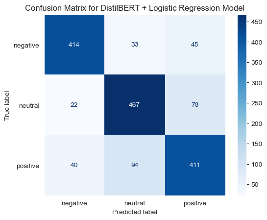

```python
# Confusion Matrix
conf_matrix = confusion_matrix(test_labels, y_pred)
# disp = ConfusionMatrixDisplay(confusion_matrix=conf_matrix, display_labels=lr_best.classes_)
disp = ConfusionMatrixDisplay(confusion_matrix=conf_matrix, display_labels=['negative',  'neutral', 'positive'])
disp.plot(cmap='Blues')
# Remove gridlines
plt.grid(False)
plt.title('Confusion Matrix for DistilBERT + Logistic Regression Model')
plt.show()
```

saving the model

```python
# Save the model
with open('./models/DB_n_LR/logistic_regression_model.pkl', 'wb') as file:
    pickle.dump(lr_best, file)
```

```python
joblib.dump(lr_best, './models/DB_n_LR/logistic_regression_model.joblib')
```

```
['./models/DB_n_LR/logistic_regression_model.joblib']
```

To load the model:

```python
# with pickle
with open('./models/DB_n_LR/logistic_regression_model.pkl', 'rb') as file:
    lr_model = pickle.load(file)
```

```python
# Load the model with joblib
lr_model = joblib.load('logistic_regression_model.joblib')
```

## 3. Pretrained Transformer

```python
# load sentiment analysis model
model_name = "distilbert-base-uncased-finetuned-sst-2-english"
sentiment_classifier = pipeline("sentiment-analysis", model= model_name)
```

```python
def analyze_sentiment(text, classifier):
    """
    function to perform sentiment analysis on a text using a model
    """
    result = classifier(text)
    return result
```

```python
%%time
# perform sentiment analysis on reviews and store results in new column
news = data["news"]
results = news.apply(lambda reviews: analyze_sentiment(reviews,sentiment_classifier))
data["sentiment_transformer"] = results.apply(lambda results: results[0]['label'])
```

```
CPU times: total: 18min 50s
Wall time: 5min 5s
```

```python
data["sentiment_transformer_score"] = results.apply(lambda results: results[0]['score'])
```

```python
data["sent_trans_NEUTRAL_SCORE"] = data["sentiment_transformer_score"].apply(lambda x: "neutral" if x < 0.989 else np.nan)
```

```python
data.info()
```

```
<class 'pandas.core.frame.DataFrame'>
Index: 8020 entries, 0 to 8020
Data columns (total 6 columns):
 #   Column                       Non-Null Count  Dtype
---  ------                       --------------  -----
 0   sentiment                    8020 non-null   object
 1   news                         8020 non-null   object
 2   sentiment_encoded            8020 non-null   int32
 3   sentiment_transformer        8020 non-null   object
 4   sentiment_transformer_score  8020 non-null   float64
 5   sent_trans_NEUTRAL_SCORE     3546 non-null   object
dtypes: float64(1), int32(1), object(4)
memory usage: 665.3+ KB
```

```python
# results
data.to_csv("D:\\Data\\PyCharmProjects\/MAS-sentiment-analysis/data/sentiment_transformer.csv")
```

```python
data_updated = pd.read_csv("D:\\Data\\PyCharmProjects\/MAS-sentiment-analysis/data/sentiment_transformer_update_v1.csv", index_col=0)
```

```python
data_updated['combine'].value_counts()
```

```
combine
neutral     3732
positive     633
negative     481
Name: count, dtype: int64
```

```python
data['sentiment'].value_counts()
```

```
sentiment
neutral     2879
positive    2725
negative    2416
Name: count, dtype: int64
```

```python
data_updated.info()
```

```
<class 'pandas.core.frame.DataFrame'>
Index: 4846 entries, 0 to 4845
Data columns (total 7 columns):
 #   Column                       Non-Null Count  Dtype
---  ------                       --------------  -----
 0   sentiment                    4846 non-null   object
 1   news                         4846 non-null   object
 2   sentiment_encoded            4846 non-null   int64
 3   sentiment_transformer        4846 non-null   object
 4   sentiment_transformer_score  4846 non-null   float64
 5   sent_trans_NEUTRAL_SCORE     2556 non-null   object
 6   combine                      4846 non-null   object
dtypes: float64(1), int64(1), object(5)
memory usage: 302.9+ KB
```

[figure not shown]

```python
# Confusion Matrix
conf_matrix = confusion_matrix(data_updated["sentiment"], data_updated["combine"])
disp = ConfusionMatrixDisplay(confusion_matrix=conf_matrix, display_labels=data_updated["sentiment"].unique())
disp.plot(cmap='Blues')
plt.title('Confusion Matrix for Pretrained Transformer')
plt.show()
```

```python
# Display a detailed classification report
print("\nClassification Report:")
print(classification_report(data_updated["sentiment"], data_updated["combine"]))
```

```
Classification Report:
              precision    recall  f1-score   support

    negative       1.00      0.80      0.89       604
     neutral       0.77      1.00      0.87      2879
    positive       1.00      0.46      0.63      1363

    accuracy                           0.82      4846
   macro avg       0.92      0.75      0.80      4846
weighted avg       0.86      0.82      0.81      4846
```

## 4. Naive Bayes Model

```python
# Preprocess the text data
def preprocess_text(text):
    # Tokenize the text
    tokens = word_tokenize(text.lower())
    # Remove punctuation
    tokens = [word for word in tokens if word.isalpha()]
    # Remove stopwords
    stop_words = set(stopwords.words('english'))
    tokens = [word for word in tokens if word not in stop_words]
    return ' '.join(tokens)
```

```python
data.info()
```

[output not shown]

```python
data['processed_news'] = data['news'].apply(preprocess_text)
```

```python
# Convert text data into numerical features
vectorizer = CountVectorizer()
X = vectorizer.fit_transform(data['processed_news'])
y = data['sentiment']
```

```python
# Split the data into training and testing sets
X_train, X_test, y_train, y_test = train_test_split(X, y, test_size=0.2, random_state=42)
```

```python
# Train a Naive Bayes model
model = MultinomialNB()
model.fit(X_train, y_train)
```

```
MultinomialNB()
```

```python
model.score(X_test, y_test)
```

[output not shown]

```python
# Predict the sentiments on the test set
y_pred = model.predict(X_test)

# Calculate accuracy and print classification report
accuracy = accuracy_score(y_test, y_pred)
print(f'Accuracy: {accuracy:.4f}')
print('Classification Report:')
print(classification_report(y_test, y_pred))
```

```
Accuracy: 0.7157
Classification Report:
              precision    recall  f1-score   support

    negative       0.72      0.84      0.77       492
     neutral       0.72      0.76      0.74       567
    positive       0.70      0.57      0.63       545

    accuracy                           0.72      1604
   macro avg       0.71      0.72      0.71      1604
weighted avg       0.71      0.72      0.71      1604
```

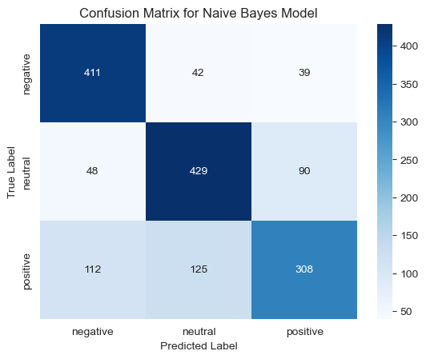

```python
# Generate the confusion matrix
conf_matrix = confusion_matrix(y_test, y_pred)

# Create a heatmap for the confusion matrix
sns.heatmap(conf_matrix, annot=True, fmt='d', cmap='Blues', xticklabels=model.classes_, yticklabels=model.classes_)
plt.xlabel('Predicted Label')
plt.ylabel('True Label')
plt.title('Confusion Matrix for Naive Bayes Model')
plt.show()
```

Hyperparameter tuning for naive bayes

```python
# Define the parameter grid
param_grid = {'alpha': [0.01, 0.1, 0.25, 0.5, 0.6, 0.65, 0.75, 1.0, 2.0, 3.0, 4.0, 5.0, 7.5, 10.0]}
```

```python
%%time
# Initialize the model
nb_model = MultinomialNB()

# Perform Grid Search

grid_search = GridSearchCV(nb_model, param_grid, cv=5, scoring='accuracy')
grid_search.fit(X_train, y_train)

# Get the best parameters and best score
best_alpha = grid_search.best_params_['alpha']
best_score = grid_search.best_score_

print(f"Best alpha: {best_alpha}")
print(f"Best cross-validation accuracy: {best_score:.4f}")
```

```
Best alpha: 0.6
Best cross-validation accuracy: 0.7316
CPU times: total: 1.66 s
Wall time: 2.22 s
```

```python
print(grid_search.best_estimator_)
```

```
MultinomialNB(alpha=0.6)
```

```python
# Train the model with the best alpha
best_model = MultinomialNB(alpha=best_alpha)
best_model.fit(X_train, y_train)

# Predict on the test set
y_pred = best_model.predict(X_test)

# Evaluate the model
accuracy = accuracy_score(y_test, y_pred)
print(f'Test set accuracy with best alpha: {accuracy:.4f}')
print('Classification Report:')
print(classification_report(y_test, y_pred))
```

```
Test set accuracy with best alpha: 0.7188
Classification Report:
              precision    recall  f1-score   support

    negative       0.72      0.84      0.78       492
     neutral       0.72      0.75      0.74       567
    positive       0.71      0.57      0.63       545

    accuracy                           0.72      1604
   macro avg       0.72      0.72      0.72      1604
weighted avg       0.72      0.72      0.71      1604
```

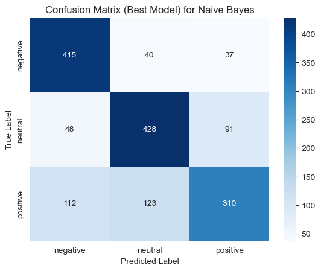

```python
# Generate the confusion matrix for the best model
conf_matrix = confusion_matrix(y_test, y_pred)

# Plot the confusion matrix
sns.heatmap(conf_matrix, annot=True, fmt='d', cmap='Blues', xticklabels=best_model.classes_, yticklabels=best_model.classes_)
plt.xlabel('Predicted Label')
plt.ylabel('True Label')
plt.title('Confusion Matrix (Best Model) for Naive Bayes')
plt.show()
```